# Machine Learning on OMOP Healthcare Data

## R Code

```r
# 1) Set working directory and load data
 setwd("/Users/jeetpatel/Desktop/Final Project")

adsl <- read_sas("adsl.sas7bdat")   # Demographics dataset
load("adae.Rda")                    # Adverse events dataset

# 2) Merge datasets by USUBJID
data <- left_join(adsl, adae, by = "USUBJID")

# 3) Inspect merged dataset
head(data)
```

```
## # A tibble: 6 × 103
##   STUDYID.x  USUBJID SUBJID SITEID.x SITEGR1 ARM   TRT01P TRT01PN TRT01A TRT01AN
##   <chr>      <chr>   <chr>  <chr>    <chr>   <chr> <chr>    <dbl> <chr>    <dbl>
## 1 CDISCPILO… 01-701… 1015   701      701     Plac… Place…       0 Place…       0
## 2 CDISCPILO… 01-701… 1015   701      701     Plac… Place…       0 Place…       0
## 3 CDISCPILO… 01-701… 1015   701      701     Plac… Place…       0 Place…       0
## 4 CDISCPILO… 01-701… 1023   701      701     Plac… Place…       0 Place…       0
## 5 CDISCPILO… 01-701… 1023   701      701     Plac… Place…       0 Place…       0
## 6 CDISCPILO… 01-701… 1023   701      701     Plac… Place…       0 Place…       0
## # ℹ 93 more variables: TRTSDT.x <date>, TRTEDT.x <date>, TRTDURD <dbl>,
## #   AVGDD <dbl>, CUMDOSE <dbl>, AGE.x <dbl>, AGEGR1.x <chr>, AGEGR1N.x <dbl>,
## #   AGEU <chr>, RACE.x <chr>, RACEN.x <dbl>, SEX.x <chr>, ETHNIC <chr>,
## #   SAFFL.x <chr>, ITTFL <chr>, EFFFL <chr>, COMP8FL <chr>, COMP16FL <chr>,
## #   COMP24FL <chr>, DISCONFL <chr>, DSRAEFL <chr>, DTHFL <chr>, BMIBL <dbl>,
## #   BMIBLGR1 <chr>, HEIGHTBL <dbl>, WEIGHTBL <dbl>, EDUCLVL <dbl>,
## #   DISONSDT <date>, DURDIS <dbl>, DURDSGR1 <chr>, VISIT1DT <date>, …
```

```r
str(data)
```

```
## tibble [1,220 × 103] (S3: tbl_df/tbl/data.frame)
##  $ STUDYID.x: chr [1:1220] "CDISCPILOT01" "CDISCPILOT01" "CDISCPILOT01" "CDISCPILOT01" ...
##   ..- attr(*, "label")= chr "Study Identifier"
##  $ USUBJID  : chr [1:1220] "01-701-1015" "01-701-1015" "01-701-1015" "01-701-1023" ...
##   ..- attr(*, "label")= chr "Unique Subject Identifier"
##  $ SUBJID   : chr [1:1220] "1015" "1015" "1015" "1023" ...
##   ..- attr(*, "label")= chr "Subject Identifier for the Study"
##  $ SITEID.x : chr [1:1220] "701" "701" "701" "701" ...
##   ..- attr(*, "label")= chr "Study Site Identifier"
##  $ SITEGR1  : chr [1:1220] "701" "701" "701" "701" ...
##   ..- attr(*, "label")= chr "Pooled Site Group 1"
##  $ ARM      : chr [1:1220] "Placebo" "Placebo" "Placebo" "Placebo" ...
##   ..- attr(*, "label")= chr "Description of Planned Arm"
##  $ TRT01P   : chr [1:1220] "Placebo" "Placebo" "Placebo" "Placebo" ...
##   ..- attr(*, "label")= chr "Planned Treatment for Period 01"
##  $ TRT01PN  : num [1:1220] 0 0 0 0 0 0 0 81 81 54 ...
##   ..- attr(*, "label")= chr "Planned Treatment for Period 01 (N)"
##  $ TRT01A   : chr [1:1220] "Placebo" "Placebo" "Placebo" "Placebo" ...
##   ..- attr(*, "label")= chr "Actual Treatment for Period 01"
##  $ TRT01AN  : num [1:1220] 0 0 0 0 0 0 0 81 81 54 ...
##   ..- attr(*, "label")= chr "Actual Treatment for Period 01 (N)"
##  $ TRTSDT.x : Date[1:1220], format: "2014-01-02" "2014-01-02" ...
##  $ TRTEDT.x : Date[1:1220], format: "2014-07-02" "2014-07-02" ...
##  $ TRTDURD  : num [1:1220] 182 182 182 28 28 28 28 180 180 14 ...
##   ..- attr(*, "label")= chr "Total Treatment Duration (Days)"
##  $ AVGDD    : num [1:1220] 0 0 0 0 0 0 0 77.7 77.7 54 ...
##   ..- attr(*, "label")= chr "Avg Daily Dose (as planned)"
##  $ CUMDOSE  : num [1:1220] 0 0 0 0 0 ...
##   ..- attr(*, "label")= chr "Cumulative Dose (as planned)"
##  $ AGE.x    : num [1:1220] 63 63 63 64 64 64 64 71 71 74 ...
##   ..- attr(*, "label")= chr "Age"
##  $ AGEGR1.x : chr [1:1220] "<65" "<65" "<65" "<65" ...
##   ..- attr(*, "label")= chr "Pooled Age Group 1"
##  $ AGEGR1N.x: num [1:1220] 1 1 1 1 1 1 1 2 2 2 ...
##   ..- attr(*, "label")= chr "Pooled Age Group 1 (N)"
##  $ AGEU     : chr [1:1220] "YEARS" "YEARS" "YEARS" "YEARS" ...
##   ..- attr(*, "label")= chr "Age Units"
##  $ RACE.x   : chr [1:1220] "WHITE" "WHITE" "WHITE" "WHITE" ...
##   ..- attr(*, "label")= chr "Race"
##  $ RACEN.x  : num [1:1220] 1 1 1 1 1 1 1 1 1 1 ...
```

[output cut: 135 more lines]

```
##  $ AESEQ    : num [1:1220] 1 2 3 1 2 3 4 1 2 NA ...
##   ..- attr(*, "label")= chr "Sequence Number"
##  $ TRTEMFL  : chr [1:1220] "Y" "Y" "Y" "Y" ...
##   ..- attr(*, "label")= chr "Treatment Emergent Analysis Flag"
##  $ AOCCFL   : chr [1:1220] "Y" "" "" "Y" ...
##   ..- attr(*, "label")= chr "1st Occurrence of Any AE Flag"
##  $ AOCCSFL  : chr [1:1220] "Y" "" "Y" "Y" ...
##   ..- attr(*, "label")= chr "1st Occurrence of SOC Flag"
##  $ AOCCPFL  : chr [1:1220] "Y" "Y" "Y" "Y" ...
##   ..- attr(*, "label")= chr "1st Occurrence of Preferred Term Flag"
##  $ AOCC02FL : chr [1:1220] "" "" "" "" ...
##   ..- attr(*, "label")= chr "1st Occurrence 02 Flag for Serious"
##  $ AOCC03FL : chr [1:1220] "" "" "" "" ...
##   ..- attr(*, "label")= chr "1st Occurrence 03 Flag for Serious SOC"
##   [list output truncated]
```

```r
summary(data)
```

```
##   STUDYID.x           USUBJID             SUBJID            SITEID.x
##  Length:1220        Length:1220        Length:1220        Length:1220
##  Class :character   Class :character   Class :character   Class :character
##  Mode  :character   Mode  :character   Mode  :character   Mode  :character
##
##
##
##
##    SITEGR1              ARM               TRT01P             TRT01PN
##  Length:1220        Length:1220        Length:1220        Min.   : 0.0
##  Class :character   Class :character   Class :character   1st Qu.: 0.0
##  Mode  :character   Mode  :character   Mode  :character   Median :54.0
##                                                           Mean   :50.1
##                                                           3rd Qu.:81.0
##                                                           Max.   :81.0
##
##     TRT01A             TRT01AN        TRTSDT.x             TRTEDT.x
##  Length:1220        Min.   : 0.0   Min.   :2012-07-09   Min.   :2012-08-28
##  Class :character   1st Qu.: 0.0   1st Qu.:2013-01-26   1st Qu.:2013-05-23
##  Mode  :character   Median :54.0   Median :2013-05-20   Median :2013-09-25
##                     Mean   :50.1   Mean   :2013-06-05   Mean   :2013-10-04
##                     3rd Qu.:81.0   3rd Qu.:2013-10-24   3rd Qu.:2014-02-20
##                     Max.   :81.0   Max.   :2014-09-02   Max.   :2015-03-05
##
##     TRTDURD          AVGDD          CUMDOSE          AGE.x
##  Min.   :  1.0   Min.   : 0.00   Min.   :    0   Min.   :51.00
##  1st Qu.: 58.0   1st Qu.: 0.00   1st Qu.:    0   1st Qu.:69.75
##  Median :134.0   Median :54.00   Median : 3888   Median :77.00
##  Mean   :121.1   Mean   :47.43   Mean   : 5186   Mean   :74.81
##  3rd Qu.:183.0   3rd Qu.:74.00   3rd Qu.: 9882   3rd Qu.:81.00
##  Max.   :212.0   Max.   :78.60   Max.   :15417   Max.   :89.00
##
##    AGEGR1.x           AGEGR1N.x         AGEU              RACE.x
##  Length:1220        Min.   :1.000   Length:1220        Length:1220
##  Class :character   1st Qu.:2.000   Class :character   Class :character
##  Mode  :character   Median :2.000   Mode  :character   Mode  :character
##                     Mean   :2.132
##                     3rd Qu.:3.000
##                     Max.   :3.000
##
```

[output cut: 153 more lines]

```
##  Length:1220        Length:1220        Length:1220        Length:1220
##  Class :character   Class :character   Class :character   Class :character
##  Mode  :character   Mode  :character   Mode  :character   Mode  :character
##
##
##
##
##    AOCC04FL           CQ01NAM            AOCC01FL            AEREL
##  Length:1220        Length:1220        Length:1220        Length:1220
##  Class :character   Class :character   Class :character   Class :character
##  Mode  :character   Mode  :character   Mode  :character   Mode  :character
##
##
##
##
```

## Functions Used

- `setwd("/Users/jeetpatel/Desktop/Final Project")` – Sets the **working directory** where the data files are stored.
- `read_sas("adsl.sas7bdat")` – Reads the **demographics dataset** into `adsl`.
- `load("adae.Rda")` – Loads the **adverse events dataset** into `adae`.
- `left_join(adsl, adae, by = "USUBJID")` – Merges the two datasets on the **common ID variable** `USUBJID` into `data`.

## Variables Created

- `adsl` → Demographics dataset
- `adae` → Adverse events dataset
- `data` → Merged dataset combining demographics and adverse events

## Summary

At the end of this step, we successfully merged the `adsl` (demographics) and `adae` (adverse events) datasets into a single dataset, `data`. An initial inspection using `head()`, `str()`, and `summary()` confirmed that the integration was successful and that all relevant patient-level information is present. This merged dataset provides a solid foundation for subsequent steps in **data cleaning, feature engineering, and machine learning modeling**.

# Data Preparation

In this section, we **prepare the merged dataset** for machine learning by selecting relevant columns, handling missing values, capping outliers, and creating the target variable.

## Objective

Prepare the dataset for modeling by:  
- Selecting only the relevant variables  
- Handling missing values  
- Capping numeric outliers  
- Creating the binary target variable for prediction

## R Code

```r
# 1) Select relevant columns and rename
data <- data[, c("USUBJID", "AGE.y", "SEX.y", "RACE.y", "DCDECOD")]
names(data)[names(data) == "AGE.y"] <- "AGE"
names(data)[names(data) == "SEX.y"] <- "SEX"
names(data)[names(data) == "RACE.y"] <- "RACE"

# 2) Handle missing values
data$AGE[is.na(data$AGE)] <- median(data$AGE, na.rm = TRUE)
data$SEX  <- fct_na_value_to_level(data$SEX, "Unknown")
data$RACE <- fct_na_value_to_level(data$RACE, "Unknown")

# 3) Cap AGE outliers at 1st and 99th percentile
age_lower <- quantile(data$AGE, 0.01)
age_upper <- quantile(data$AGE, 0.99)
data$AGE[data$AGE < age_lower] <- age_lower
data$AGE[data$AGE > age_upper] <- age_upper

# 4) Remove rows with missing DCDECOD
data <- data[!is.na(data$DCDECOD), ]

# 5) Create binary target variable and remove original column
data$completed_flag <- factor(ifelse(data$DCDECOD == "COMPLETED", "Yes", "No"))
data <- data[, !(names(data) %in% "DCDECOD")]

# 6) Check target variable balance
table(data$completed_flag)
```

```
##
##  No Yes
## 684 536
```

## Functions Used

- `data[, c(...)]` – Selects columns of interest.
- `names(data)[...] <- ...` – Renames columns for clarity.
- `is.na()` / `median(..., na.rm=TRUE)` – Handles missing numeric values.
- `fct_na_value_to_level()` – Replaces missing factor values with a specific level (“Unknown”).
- `quantile()` – Computes percentiles for capping numeric outliers.
- `factor(ifelse(...))` – Creates a binary categorical target variable.
- `table()` – Displays the frequency counts of the target variable.

## Variables Created

- `AGE`, `SEX`, `RACE` → Cleaned predictor variables
- `completed_flag` → Binary target variable (“Yes”/“No”)
- `data` → Updated dataset ready for modeling

## Summary

After this step:  
- The dataset contains only the **necessary predictors** (`AGE`, `SEX`, `RACE`) and the **target variable** (`completed_flag`).  
- Missing values have been handled, numeric outliers capped, and the dataset is **ready for train/test splitting and modeling**.

# Exploratory Data Analysis

In this section, we **explore the cleaned dataset** to understand its structure, variable distributions, and class balance.

## Objective

- Inspect dataset structure and variable types
- Summarize numeric and categorical variables
- Visualize the distribution of the target variable (`completed_flag`)

## R Code

```r
# 1) Overview of dataset structure and types
glimpse(data)
```

```
## Rows: 1,220
## Columns: 5
## $ USUBJID        <chr> "01-701-1015", "01-701-1015", "01-701-1015", "01-701-10…
## $ AGE            <dbl> 63, 63, 63, 64, 64, 64, 64, 71, 71, 77, 77, 77, 85, 85,…
## $ SEX            <fct> F, F, F, M, M, M, M, M, M, Unknown, F, F, F, F, F, F, M…
## $ RACE           <fct> WHITE, WHITE, WHITE, WHITE, WHITE, WHITE, WHITE, WHITE,…
## $ completed_flag <fct> Yes, Yes, Yes, No, No, No, No, Yes, Yes, No, Yes, Yes, …
```

```r
# 2) Summary statistics for numeric and categorical variables
summary(data)
```

```
##    USUBJID               AGE             SEX
##  Length:1220        Min.   :56.00   F      :595
##  Class :character   1st Qu.:70.00   M      :596
##  Mode  :character   Median :77.00   Unknown: 29
##                     Mean   :74.91
##                     3rd Qu.:81.00
##                     Max.   :88.00
##                                RACE      completed_flag
##  AMERICAN INDIAN OR ALASKA NATIVE:  15   No :684
##  BLACK OR AFRICAN AMERICAN       :  90   Yes:536
##  WHITE                           :1086
##  Unknown                         :  29
##
##
```

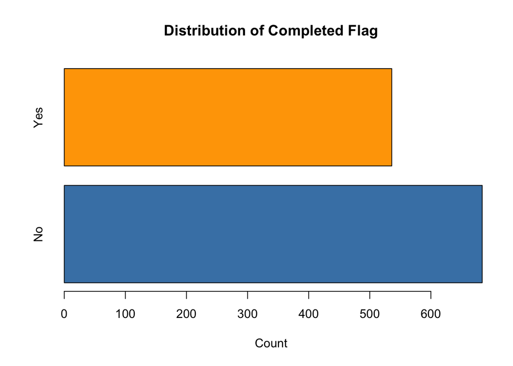

```r
# 3) Visualize target variable distribution
completed_counts <- table(data$completed_flag)
barplot(completed_counts,
        horiz = TRUE,
        col = c("steelblue", "orange"),
        main = "Distribution of Completed Flag",
        xlab = "Count")
```

## Functions Used

- `glimpse()` – Compactly shows variable types and first values; ideal for wide datasets.
- `summary()` – Provides summary statistics for numeric variables and counts for factors.
- `table()` – Counts occurrences of each category (here, `completed_flag`).
- `barplot()` – Visualizes the distribution of a categorical variable.

## Variables Created

- `completed_counts` → Frequency counts of `completed_flag` categories

## Summary

After this step:  
- The dataset structure, variable types, and summary statistics are reviewed.  
- The target variable `completed_flag` shows class distribution, visualized via a barplot.  
- This EDA ensures understanding of the dataset before modeling.

# Machine Learning Model

In this section, we **prepare the dataset for modeling** by splitting it into training and testing sets and defining preprocessing steps for machine learning.

## Train/Test Split

### Objective

- Divide the dataset into **training** and **testing** sets
- Maintain the target variable distribution using stratified sampling

### R Code

```r
set.seed(123)
split <- initial_split(data, prop = 0.8, strata = completed_flag)
train <- training(split)
test  <- testing(split)
```

### Functions Used

- `set.seed()` – Ensures reproducibility of random operations
- `initial_split()` – Splits data into training/testing sets
- `training()` / `testing()` – Extracts the training and testing datasets from the split object

### Variables Created

- `split` → Object storing the train/test split
- `train` → Training dataset for fitting models
- `test` → Testing dataset for evaluating models

### Summary

After this step:  
- The dataset is divided into training and testing sets.  
- The target variable’s class distribution is maintained in both sets, ensuring reliable model evaluation.

## Preprocessing Recipe

### Objective

Define feature preprocessing for machine learning:  
- Encode categorical variables  
- Normalize numeric variables

### R Code

```r
rec <- recipe(completed_flag ~ AGE + SEX + RACE, data = train)
rec <- step_dummy(rec, all_nominal_predictors()) # One-hot encode categorical variables
rec <- step_normalize(rec, all_numeric_predictors()) # Standardize numeric variables
```

### Functions Used

- `recipe()` – Creates a preprocessing blueprint specifying outcome and predictors
- `step_dummy()` – Converts categorical variables into dummy/one-hot encoded features
- `step_normalize()` – Standardizes numeric predictors

### Variables Created

- `rec` → Preprocessing recipe ready for model training

### Summary

After this step:  
- The preprocessing recipe defines all necessary transformations for modeling.  
- Categorical predictors are encoded, and numeric predictors are normalized.  
- The dataset is fully prepared for training machine learning models.

## Logistic Regression & Random Forest

### Objective

Train and compare two classification models:  
- **Logistic Regression (glm engine)** – interpretable baseline model  
- **Random Forest (ranger engine, 500 trees)** – flexible ensemble model with feature importance

### R Code

```r
# 1) Logistic Regression Model
log_model <- logistic_reg(mode = "classification")
log_model <- set_engine(log_model, "glm")

log_wf <- workflow()
log_wf <- add_recipe(log_wf, rec)
log_wf <- add_model(log_wf, log_model)

log_fit <- fit(log_wf, data = train)


# 2) Random Forest Model
rf_model <- rand_forest(mode = "classification", trees = 500)
rf_model <- set_engine(rf_model, "ranger", importance = "impurity")

rf_wf <- workflow()
rf_wf <- add_recipe(rf_wf, rec)
rf_wf <- add_model(rf_wf, rf_model)

set.seed(123)
rf_fit <- fit(rf_wf, data = train)
```

### Functions Used

- `logistic_reg(mode = "classification")` – Defines logistic regression model for classification
- `rand_forest(mode = "classification", trees = 500)` – Defines random forest model with 500 trees
- `set_engine("glm")` – Uses **glm** as logistic regression engine
- `set_engine("ranger", importance = "impurity")` – Uses **ranger** as random forest engine and computes feature importance
- `workflow()` – Creates a workflow object for preprocessing + model
- `add_recipe()` – Adds preprocessing recipe
- `add_model()` – Adds chosen model specification
- `fit()` – Trains the workflow on the training dataset

### Variables Created

- `log_model` → Logistic regression model specification
- `log_wf` → Workflow for logistic regression
- `log_fit` → Trained logistic regression model
- `rf_model` → Random forest model specification
- `rf_wf` → Workflow for random forest
- `rf_fit` → Trained random forest model

### Summary

- Logistic Regression provides a **simple, interpretable baseline** for classification.
- Random Forest builds an **ensemble of 500 decision trees**, handling nonlinearities and providing feature importance.
- Both models are trained on the **same preprocessing recipe** for fair comparison.

## Model Evaluation

### Objective

Evaluate the performance of Logistic Regression and Random Forest models on the test dataset.  
Additionally, assess feature importance for the Random Forest model.

### R Code

```r
# 13) Evaluate Logistic Regression
log_preds <- bind_cols(predict(log_fit, test), select(test, completed_flag))
log_metrics <- metrics(log_preds, truth = completed_flag, estimate = .pred_class)
log_cm      <- conf_mat(log_preds, truth = completed_flag, estimate = .pred_class)

log_metrics
```

```
## # A tibble: 2 × 3
##   .metric  .estimator .estimate
##   <chr>    <chr>          <dbl>
## 1 accuracy binary        0.514
## 2 kap      binary       -0.0479
```

```r
log_cm
```

```
##           Truth
## Prediction  No Yes
##        No  108  90
##        Yes  29  18
```

```r
# 14) Evaluate Random Forest
rf_preds <- bind_cols(predict(rf_fit, test), select(test, completed_flag))
rf_metrics <- metrics(rf_preds, truth = completed_flag, estimate = .pred_class)
rf_cm      <- conf_mat(rf_preds, truth = completed_flag, estimate = .pred_class)

rf_metrics
```

```
## # A tibble: 2 × 3
##   .metric  .estimator .estimate
##   <chr>    <chr>          <dbl>
## 1 accuracy binary         0.649
## 2 kap      binary         0.236
```

```r
rf_cm
```

```
##           Truth
## Prediction  No Yes
##        No  129  78
##        Yes   8  30
```

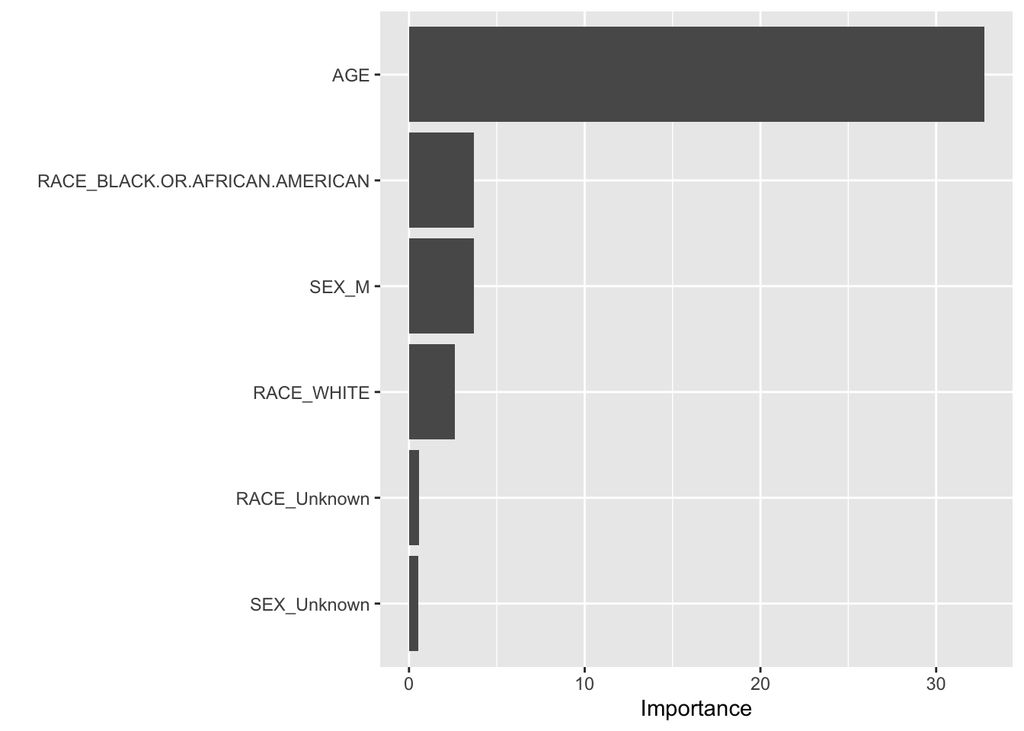

```r
# 15) Feature Importance for Random Forest
rf_fit_parsnip <- extract_fit_parsnip(rf_fit)
vip(rf_fit_parsnip)
```

### Functions Used

- `predict()` – Generates predictions from the trained model
- `bind_cols()` – Combines predictions with the actual test labels
- `select()` – Extracts the outcome variable from the test dataset
- `metrics()` – Calculates accuracy and other classification metrics
- `conf_mat()` – Produces a confusion matrix for model predictions
- `extract_fit_parsnip()` – Extracts the underlying fitted model from the workflow
- `vip()` – Visualizes feature importance from the random forest

### Variables Created

- `log_preds` → Logistic regression predictions on test data
- `log_metrics` → Evaluation metrics for logistic regression
- `log_cm` → Confusion matrix for logistic regression
- `rf_preds` → Random forest predictions on test data
- `rf_metrics` → Evaluation metrics for random forest
- `rf_cm` → Confusion matrix for random forest
- `rf_fit_parsnip` → Extracted fitted random forest model for feature importance

### Summary

- Logistic Regression and Random Forest are evaluated on the test dataset.
- **Metrics** and **confusion matrices** provide insights into classification performance.
- Random Forest additionally provides **feature importance**, showing which predictors contribute most to the model.

# Conclusion

- **Logistic Regression** achieved 51.4% accuracy with a Cohen’s Kappa of -0.048, indicating no predictive power beyond chance.
- **Random Forest** improved accuracy to 64.9% with a Kappa of 0.236, showing modest predictive ability. It was more effective in identifying **non-completers** but still struggled with predicting **completers**.
- **Feature importance analysis** revealed that **Age** was the strongest predictor, followed by **sex** and **race**, aligning with clinical expectations that older participants may face more barriers to completion.

While not yet ready for clinical deployment, the findings support the hypothesis that baseline demographic variables carry predictive signal for trial completion.

## Key Insights & Real-World Impact

- **Model Trade-offs:** Logistic Regression offered interpretability but weak performance; Random Forest improved predictive ability at the cost of transparency.
- **Clinical Concern:** False negatives remain critical, as missed identification of at-risk patients reduces opportunities for timely support.
- **Healthcare Impact:** Predictive models could help trial coordinators **identify participants at risk of dropping out** and intervene with personalized support (e.g., reminders, transport aid, flexible scheduling). This can **reduce trial costs, improve retention, and accelerate drug development**.

## Next Steps

- **Enhance Features:** Incorporate clinical and behavioral variables (e.g., health conditions, engagement data).
- **Model Optimization:** Tune Random Forest and test more advanced ensemble methods.
- **Interpretability:** Apply SHAP or LIME to make predictions more transparent for clinical use.